# Kiss, Pieper, Börner (2022): EXP 1

Tibor Kiss

29.08.2022, 26.10.2022, 23.03.2023

### Analysis of experimental study on affirmative and privative senses

This document provides the analysis for the experimental study on affirmative and privative senses used in Kiss, Pieper, Börner (2023) (EXP 1), revised version after reviews, including the random slopes on the interaction of main effects.

The analysis differs from earlier versions in that we now use affirmative senses as reference values. Also, the experiments make now use of the term *SENSE* to distinguish affirmative from privative interpretations of event-internal modifiers. Earlier version used *Thematic Integration* instead.

#### Read in required libraries

```r
library(lme4)
library(tidyverse)
library(emmeans)
library(kableExtra)

show(version)
```

```
##                _
## platform       aarch64-apple-darwin20
## arch           aarch64
## os             darwin20
## system         aarch64, darwin20
## status
## major          4
## minor          2.1
## year           2022
## month          06
## day            23
## svn rev        82513
## language       R
## version.string R version 4.2.1 (2022-06-23)
## nickname       Funny-Looking Kid
```

#### Summary of test items for EXP 1

The following table contains the minimal pairs of test items used in EXP 1. Minimal pairs `t1` - `t12` contain subject-oriented `comitatives`, minimal pairs `t13` - `t24` contain `instrumentals`. Further information on the test item pairs is provided in the file `Data/stimuli_test_further_annotation.csv`.

| Test Item Pair | PP > OBJ | OBJ > PP |
| --- | --- | --- |
| t01 | Max hat erzählt, dass ein Tropenarzt zusammen mit einer Krankenschwester was verteilt hat. Was es war, weiß ich aber nicht. | Max hat erzählt, dass ein Tropenarzt was zusammen mit einer Krankenschwester verteilt hat. Was es war, weiß ich aber nicht. |
| t02 | Ich habe gehört, dass ein Minister zusammen mit einem General was unterzeichnet hat. Was es war, weiß ich aber nicht. | Ich habe gehört, dass ein Minister was zusammen mit einem General unterzeichnet hat. Was es war, weiß ich aber nicht. |
| t03 | Kim hat erzählt, dass ein Soziologe zusammen mit einem Psychologen was untersucht hat. Was es war, weiß ich aber nicht. | Kim hat erzählt, dass ein Soziologe was zusammen mit einem Psychologen untersucht hat. Was es war, weiß ich aber nicht. |
| t04 | Eva hat erzählt, dass ein Virologe zusammen mit einem Pharmakologen was getestet hat. Was es war, weiß ich aber nicht. | Eva hat erzählt, dass ein Virologe was zusammen mit einem Pharmakologen getestet hat. Was es war, weiß ich aber nicht. |
| t05 | Ich habe gehört, dass ein Firmenchef zusammen mit einem Forscher was entwickelt hat. Was es war, weiß ich aber nicht. | Ich habe gehört, dass ein Firmenchef was zusammen mit einem Forscher entwickelt hat. Was es war, weiß ich aber nicht. |
| t06 | Pia hat erzählt, dass ein Gemeindevertreter zusammen mit einem Sachverständigen was ausgearbeitet hat. Was es war, weiß ich aber nicht. | Pia hat erzählt, dass ein Gemeindevertreter was zusammen mit einem Sachverständigen ausgearbeitet hat. Was es war, weiß ich aber nicht. |
| t07 | Ich habe gehört, dass ein Tourist ganz ohne einen Reisebegleiter was erkundet hat. Was es war, weiß ich aber nicht. | Ich habe gehört, dass ein Tourist was ganz ohne einen Reisebegleiter erkundet hat. Was es war, weiß ich aber nicht. |
| t08 | Ich habe gehört, dass ein Offizier ganz ohne einen Berater was entschieden hat. Was es war, weiß ich aber nicht. | Ich habe gehört, dass ein Offizier was ganz ohne einen Berater entschieden hat. Was es war, weiß ich aber nicht. |
| t09 | Jan hat erzählt, dass ein Saxofonist ganz ohne einen Cellisten was aufgeführt hat. Was es war, weiß ich aber nicht. | Jan hat erzählt, dass ein Saxofonist was ganz ohne einen Cellisten aufgeführt hat. Was es war, weiß ich aber nicht. |
| t10 | Ben hat erzählt, dass ein Schriftsteller ganz ohne einen Philologen was übersetzt hat. Was es war, weiß ich aber nicht. | Ben hat erzählt, dass ein Schriftsteller was ganz ohne einen Philologen übersetzt hat. Was es war, weiß ich aber nicht. |
| t11 | Ich habe gehört, dass ein Polizist ganz ohne einen Kollegen was überprüft hat. Was es war, weiß ich aber nicht. | Ich habe gehört, dass ein Polizist was ganz ohne einen Kollegen überprüft hat. Was es war, weiß ich aber nicht. |
| t12 | Uwe hat erzählt, dass ein Hausmeister ganz ohne einen Helfer was aufgehängt hat. Was es war, weiß ich aber nicht. | Uwe hat erzählt, dass ein Hausmeister was ganz ohne einen Helfer aufgehängt hat. Was es war, weiß ich aber nicht. |
| t13 | Ich habe gehört, dass ein Angestellter über einen Grafikeditor was erstellt hat. Was es war, weiß ich aber nicht. | Ich habe gehört, dass ein Angestellter was über einen Grafikeditor erstellt hat. Was es war, weiß ich aber nicht. |
| t14 | Ben hat erzählt, dass ein Geschäftsmann über eine Kreditkarte was abgerechnet hat. Was es war, weiß ich aber nicht. | Ben hat erzählt, dass ein Geschäftsmann was über eine Kreditkarte abgerechnet hat. Was es war, weiß ich aber nicht. |
| t15 | Lea hat erzählt, dass ein Hacker über einen Computer was gesteuert hat. Was es war, weiß ich aber nicht. | Lea hat erzählt, dass ein Hacker was über einen Computer gesteuert hat. Was es war, weiß ich aber nicht. |
| t16 | Ich habe gehört, dass ein Busfahrer über ein Mikrofon was angekündigt hat. Was es war, weiß ich aber nicht. | Ich habe gehört, dass ein Busfahrer was über ein Mikrofon angekündigt hat. Was es war, weiß ich aber nicht. |
| t17 | Ich habe gehört, dass ein Schüler über eine Kamera was beobachtet hat. Was es war, weiß ich aber nicht. | Ich habe gehört, dass ein Schüler was über eine Kamera beobachtet hat. Was es war, weiß ich aber nicht. |
| t18 | Max hat erzählt, dass ein Pfleger über eine Pipette was verabreicht hat. Was es war, weiß ich aber nicht. | Max hat erzählt, dass ein Pfleger was über eine Pipette verabreicht hat. Was es war, weiß ich aber nicht. |
| t19 | Eva hat erzählt, dass eine Hausfrau ganz ohne ein Spülmittel was gereinigt hat. Was es war, weiß ich aber nicht. | Eva hat erzählt, dass eine Hausfrau was ganz ohne ein Spülmittel gereinigt hat. Was es war, weiß ich aber nicht. |
| t20 | Ich habe gehört, dass ein Zimmerer ganz ohne einen Dübel was befestigt hat. Was es war, weiß ich aber nicht. | Ich habe gehört, dass ein Zimmerer was ganz ohne einen Dübel befestigt hat. Was es war, weiß ich aber nicht. |
| t21 | Ich habe gehört, dass ein Techniker ganz ohne ein Hilfsmittel was angeschlossen hat. Was es war, weiß ich aber nicht. | Ich habe gehört, dass ein Techniker was ganz ohne ein Hilfsmittel angeschlossen hat. Was es war, weiß ich aber nicht. |
| t22 | Pia hat erzählt, dass ein Hausbesitzer ganz ohne einen Schlüssel was geöffnet hat. Was es war, weiß ich aber nicht. | Pia hat erzählt, dass ein Hausbesitzer was ganz ohne einen Schlüssel geöffnet hat. Was es war, weiß ich aber nicht. |
| t23 | Ich habe gehört, dass ein Assistent ganz ohne einen Spachtel was aufgetragen hat. Was es war, weiß ich aber nicht. | Ich habe gehört, dass ein Assistent was ganz ohne einen Spachtel aufgetragen hat. Was es war, weiß ich aber nicht. |
| t24 | Jan hat erzählt, dass ein Tüftler ganz ohne eine Batterie was betrieben hat. Was es war, weiß ich aber nicht. | Jan hat erzählt, dass ein Tüftler was ganz ohne eine Batterie betrieben hat. Was es war, weiß ich aber nicht. |

#### Read in data set

We’ll use more perspicuous names to address `subjects` and `items`.

```r
data <-
  read.csv("../Data/ForcedChoice_test.csv", fileEncoding = "UTF-8") %>%
  mutate(ANSWER = factor(ANSWER),
         SENSE = factor(ifelse(INTEGRATION == "yes", "affirmative", "privative")),
         ADVERBIAL_TYPE = factor(ADVERBIAL_TYPE),
         subjects = factor(workerId),
         items = factor(ENCODING))


summary(data)
```

```
##     workerId        itemId            ENCODING         OPTION_0_CONDITION_NO
##  Min.   :220.0   Length:792         Length:792         Min.   :1
##  1st Qu.:229.0   Class :character   Class :character   1st Qu.:1
##  Median :239.0   Mode  :character   Mode  :character   Median :1
##  Mean   :241.7                                         Mean   :1
##  3rd Qu.:254.0                                         3rd Qu.:1
##  Max.   :271.0                                         Max.   :1
##
##  OPTION_1_CONDITION_NO ADVERBIAL_TYPE INTEGRATION           ANSWER
##  Min.   :2             COM(S):396     Length:792         OBJ>PP:443
##  1st Qu.:2             INSTR :396     Class :character   PP>OBJ:349
##  Median :2                            Mode  :character
##  Mean   :2
##  3rd Qu.:2
##  Max.   :2
##
##  ANSWER_CONDITION_NO ANSWER_POSITION    PRESENTATION_ORDER
##  Min.   :1.000       Length:792         Length:792
##  1st Qu.:1.000       Class :character   Class :character
##  Median :2.000       Mode  :character   Mode  :character
##  Mean   :1.559
##  3rd Qu.:2.000
##  Max.   :2.000
##
##  PRESENTATION_ORDER_CONDITION       rt          time_elapsed     trial_index
##  Length:792                   Min.   :  3258   Min.   : 38941   Min.   : 6.00
##  Class :character             1st Qu.:  6920   1st Qu.:225297   1st Qu.:22.00
##  Mode  :character             Median :  8786   Median :378208   Median :38.00
##                               Mean   : 10144   Mean   :379628   Mean   :37.99
##                               3rd Qu.: 11496   3rd Qu.:515928   3rd Qu.:54.00
##                               Max.   :204821   Max.   :927880   Max.   :70.00
##
##          SENSE        subjects       items
##  affirmative:396   220    : 24   t01    : 33
##  privative  :396   221    : 24   t02    : 33
##                    222    : 24   t03    : 33
##                    223    : 24   t04    : 33
##                    224    : 24   t05    : 33
##                    225    : 24   t06    : 33
##                    (Other):648   (Other):594
```

#### Empirical distribution of choices

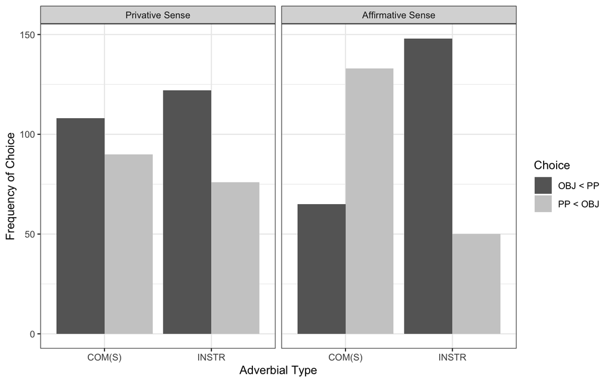

```r
int.labels <- c("Privative Sense", "Affirmative Sense")
names(int.labels) <- c("privative", "affirmative")

summary <-
  data %>%
  group_by(ADVERBIAL_TYPE, SENSE, ANSWER) %>%
  summarise(count = n()) %>%
  as.data.frame()

summary$SENSE <- relevel(summary$SENSE, ref = "privative")

ggplot(summary, aes(x = ADVERBIAL_TYPE, y = count, fill = ANSWER)) +
  geom_bar(stat = "identity", position = "dodge") +
  labs(x = "Adverbial Type", y = "Frequency of Choice") +
  facet_wrap(~SENSE, labeller = labeller(SENSE = int.labels)) +
  scale_fill_manual(name = "Choice", values = c("grey40", "grey80"),
                    labels = c("OBJ < PP", "PP < OBJ")) +
  theme_bw()
```

```r
ggsave("../Figures/emp_dist_exp_1.pdf")

summary.wide <-
  summary %>%
  spread(key = ANSWER, value = count)

summary.wide
```

```
##   ADVERBIAL_TYPE       SENSE OBJ>PP PP>OBJ
## 1         COM(S)   privative    108     90
## 2         COM(S) affirmative     65    133
## 3          INSTR   privative    122     76
## 4          INSTR affirmative    148     50
```

#### Alternative requested by reviewer

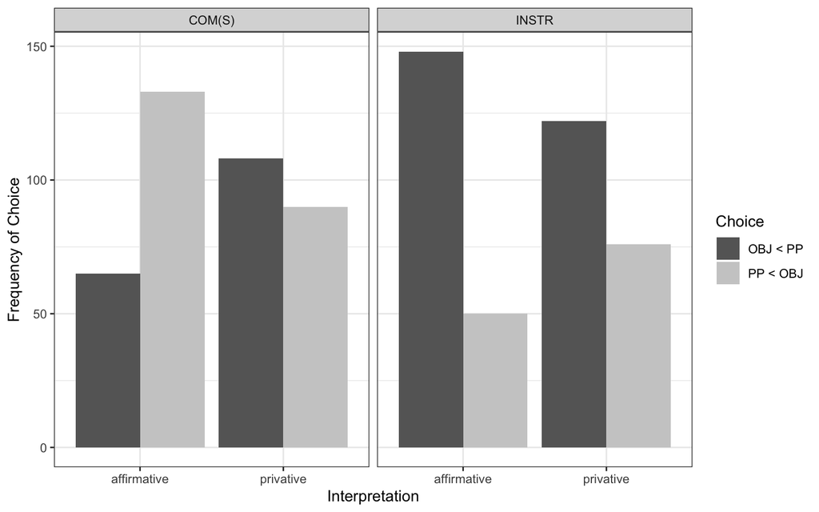

```r
adv.labels <- c("COM(S)", "INSTR")
names(adv.labels) <- c("COM(S)", "INSTR")

summary$SENSE <- relevel(summary$SENSE, ref = "affirmative") ## have to switch back

ggplot(summary, aes(x = SENSE, y = count, fill = ANSWER)) +
  geom_bar(stat = "identity", position = "dodge") +
  labs(x = "Interpretation", y = "Frequency of Choice") +
  facet_wrap(~ADVERBIAL_TYPE, labeller = labeller(ADVERBIAL_TYPE = adv.labels)) +
  scale_fill_manual(name = "Choice", values = c("grey40", "grey80"),
                    labels = c("OBJ < PP", "PP < OBJ")) +
  theme_bw()
```

```r
ggsave("../Figures/emp_dist_exp_1_alt.pdf")
```

The graphical representation of the empirical distribution of choices suggests an interaction between the main effects, as is witnessed by the inversion of the distribution of `COM(S)` under `affirmative sense`.

#### Random Slope Model with interaction

Please notice that the random structure does not assume intercepts, because we want to obtain information on by-subject variance (i.e. `subjects`) for each condition. We’ll have to consider possible spurious convergence warnings, and apply tests from https://rstudio-pubs-static.s3.amazonaws.com/33653_57fc7b8e5d484c909b615d8633c01d51.html, i.e. Ben Bolker’s troubleshooting page for spurious convergence errors. In the present case, the warning can be shown to be a false positive by simply restarting the optimization with the values from the first run.

```r
data$SENSE <-
  relevel(data$SENSE, ref = "affirmative")
data$ADVERBIAL_TYPE <-
  relevel(data$ADVERBIAL_TYPE, ref = "INSTR")

model <-
  glmer(formula = ANSWER ~ ADVERBIAL_TYPE * SENSE +
          (0 + ADVERBIAL_TYPE * SENSE | subjects) + (1 | items),
        data = data, family = binomial())
```

```
## Warning in checkConv(attr(opt, "derivs"), opt$par, ctrl = control$checkConv, : Model failed to converge with max|grad| = 0.0252886 (tol = 0.002, component 1)
```

```r
start <-
  getME(model, c("theta", "fixef"))

model <-
  update(model, start = start,
         control=glmerControl(optCtrl=list(maxfun=2e4)))


options(width = 300)
print(summary(model), corr = FALSE)
```

```
## Generalized linear mixed model fit by maximum likelihood (Laplace Approximation) ['glmerMod']
##  Family: binomial  ( logit )
## Formula: ANSWER ~ ADVERBIAL_TYPE * SENSE + (0 + ADVERBIAL_TYPE * SENSE |      subjects) + (1 | items)
##    Data: data
## Control: glmerControl(optCtrl = list(maxfun = 20000))
##
##      AIC      BIC   logLik deviance df.resid
##    970.0   1040.2   -470.0    940.0      777
##
## Scaled residuals:
##     Min      1Q  Median      3Q     Max
## -2.2556 -0.6492 -0.3626  0.7372  2.5659
##
## Random effects:
##  Groups   Name                                Variance Std.Dev. Corr
##  subjects ADVERBIAL_TYPEINSTR                 0.747688 0.86469
##           ADVERBIAL_TYPECOM(S)                0.512001 0.71554   0.68
##           SENSEprivative                      1.153457 1.07399  -0.12  0.38
##           ADVERBIAL_TYPECOM(S):SENSEprivative 0.235485 0.48527   0.37 -0.16 -0.97
##  items    (Intercept)                         0.001408 0.03753
## Number of obs: 792, groups:  subjects, 33; items, 24
##
## Fixed effects:
##                                     Estimate Std. Error z value Pr(>|z|)
## (Intercept)                          -1.2602     0.2518  -5.005 5.59e-07 ***
## ADVERBIAL_TYPECOM(S)                  2.0591     0.2861   7.198 6.13e-13 ***
## SENSEprivative                        0.6287     0.3275   1.920   0.0549 .
## ADVERBIAL_TYPECOM(S):SENSEprivative  -1.6501     0.3651  -4.520 6.18e-06 ***
## ---
## Signif. codes:  0 '***' 0.001 '**' 0.01 '*' 0.05 '.' 0.1 ' ' 1
```

### Model predictions

```r
predictions <-
  emmeans(model, pairwise~ADVERBIAL_TYPE * SENSE,
          type = "response")

predictions$emmeans
```

```
##  ADVERBIAL_TYPE SENSE        prob     SE  df asymp.LCL asymp.UCL
##  INSTR          affirmative 0.221 0.0433 Inf     0.148     0.317
##  COM(S)         affirmative 0.690 0.0449 Inf     0.596     0.770
##  INSTR          privative   0.347 0.0651 Inf     0.233     0.483
##  COM(S)         privative   0.445 0.0644 Inf     0.324     0.572
##
## Confidence level used: 0.95
## Intervals are back-transformed from the logit scale
```

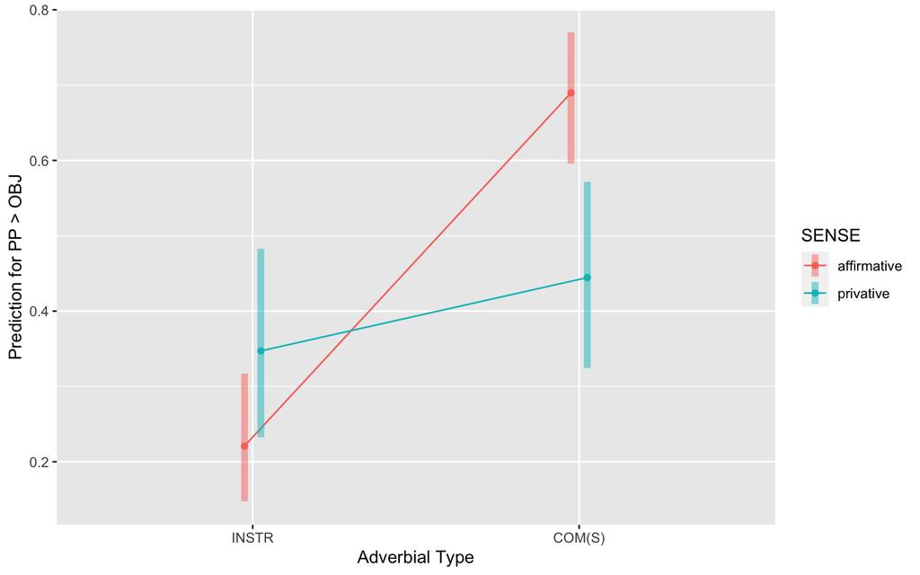

```r
## also response useful, now switched to predictor for effects
## if lp is used, y = emmean, if response is used y = prob

emmip(model, SENSE ~ ADVERBIAL_TYPE, type = "response", CIs = TRUE,
      xlab = "Adverbial Type", ylab = "Prediction for PP > OBJ")
```

```r
ggsave("../Figures/EXP_1.preds.pdf")
```

### Choices for privative test items

The following summary and plot identifies the number of answers `PP > OBJ` for test items with privative senses for both adverbial types.

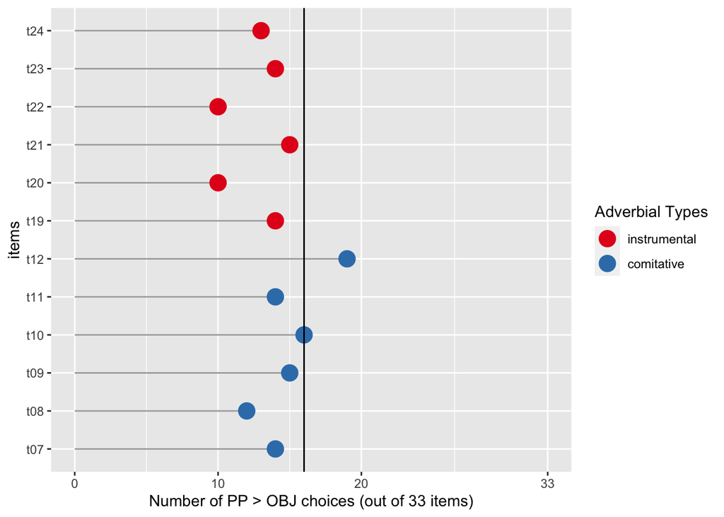

```r
privative.sum <-
  data %>%
  filter(items %in% c("t07", "t08", "t09", "t10", "t11", "t12",
                      "t19", "t20", "t21", "t22", "t23", "t24")) %>%
  group_by(items, ADVERBIAL_TYPE, ANSWER) %>%
  summarize(Count = n()) %>%
  filter(ANSWER == "PP>OBJ") %>%
  as.data.frame()

ggplot(privative.sum, aes(x = Count, y = items, color = ADVERBIAL_TYPE)) +
  geom_segment(aes(x = 0, xend = Count, yend = items), color="darkgrey") +
  geom_point(size=5) +
  scale_color_brewer(name = "Adverbial Types", labels = c("instrumental", "comitative"),
                     palette = "Set1") +
  scale_x_continuous(breaks = c(0, 10, 20, 33), limits = c(0, 33)) +
  geom_vline(xintercept = 16) +
  labs(x = "Number of PP > OBJ choices (out of 33 items)")
```

```r
ggsave("../Figures/EXP_1.choices.pdf")
```

### Plotting correlations for random effects

In the following, we plot correlations between the conditions, based on random effects.

```r
ranef.df <- data.frame(ranef(model)$subjects)
ranef.df$participants <- rownames(ranef.df)
colnames(ranef.df)[1:4] <- c("INSTR_aff", "COMS_aff", "INSTR_priv", "COMS_priv")

# ranef.df <- ranef.df %>%
#  mutate(INSTR_aff = INSTR_aff + model@beta[1]) %>%
#  mutate(COMS_aff = COMS_aff + model@beta[2]) %>%
#  mutate(INSTR_priv = INSTR_priv + model@beta[3]) %>%
#  mutate(COMS_priv = COMS_priv + model@beta[4]) %>%
#  arrange(COMS_aff)

ranef.df <- ranef.df %>%
  arrange(COMS_aff)
```

We make use of `VarCorr(model2)` to extract the correlation parameters from the model (which are correlations of standard deviations).

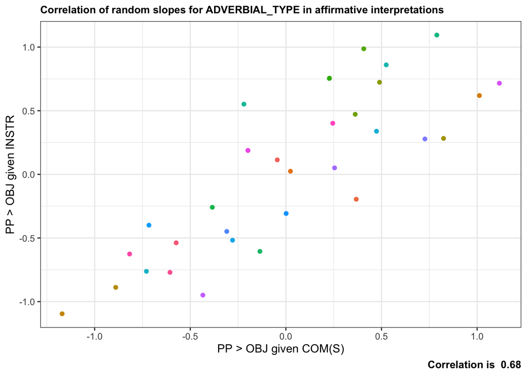

```r
cor_vals <- data.frame(VarCorr(model))

ggplot(ranef.df, aes(y = INSTR_aff, x = COMS_aff)) +
  geom_point(aes(color = participants), show.legend = FALSE) +
  labs(y = "PP > OBJ given INSTR",
       x = "PP > OBJ given COM(S)",
       subtitle = "Correlation of random slopes for ADVERBIAL_TYPE in affirmative interpretations",
       caption = paste("Correlation is ", round(cor_vals$sdcor[5], 2))) +
  theme_bw() +
  theme(plot.caption = element_text(face = "bold", size = 10),
        plot.subtitle = element_text(face = "bold", size = 10))
```

```r
ggsave("../Figures/EXP_1.INSTR_COM_S_aff.pdf")
```

The positive correlation between affirmative instrumental and comitative interpretations becomes clearly visible here. Speakers which are more restrictive towards `INSTR > OBJ` are also somewhat restrictive towards `COM(S) > OBJ`. One could assume the influence of the categorial constraint `NP > PP` here. (But this appears to be contradicted by the negative correlation for **privative** interpretations of `INSTR` and `COM(S)`.)

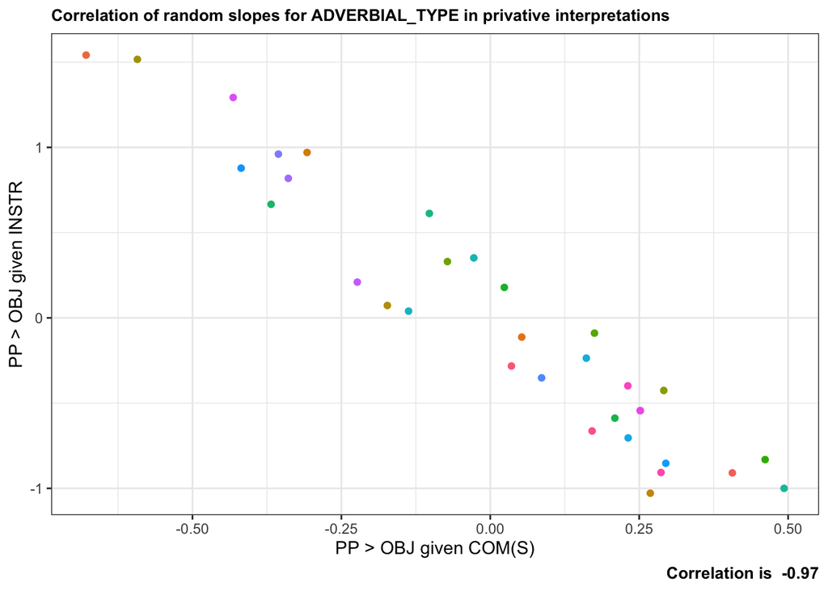

```r
ggplot(ranef.df, aes(y = INSTR_priv, x = COMS_priv)) +
  geom_point(aes(color = participants), show.legend = FALSE) +
  labs(y = "PP > OBJ given INSTR",
       x = "PP > OBJ given COM(S)",
       subtitle = "Correlation of random slopes for ADVERBIAL_TYPE in privative interpretations",
       caption = paste("Correlation is ", round(cor_vals$sdcor[10], 2))) +
  theme_bw() +
  theme(plot.caption = element_text(face = "bold", size = 10),
        plot.subtitle = element_text(face = "bold", size = 10))
```

```r
ggsave("../Figures/EXP_1.INSTR_COM_S_priv.pdf")
```

Here, we observe a strong negative correlation, which also leads to a (largely unexplained) reversal of preferences in case of privative instrumentals: speakers are most restrictive towards the order `PP > OBJ` for `COM(S)` prefer the same order for privative `INSTR`.

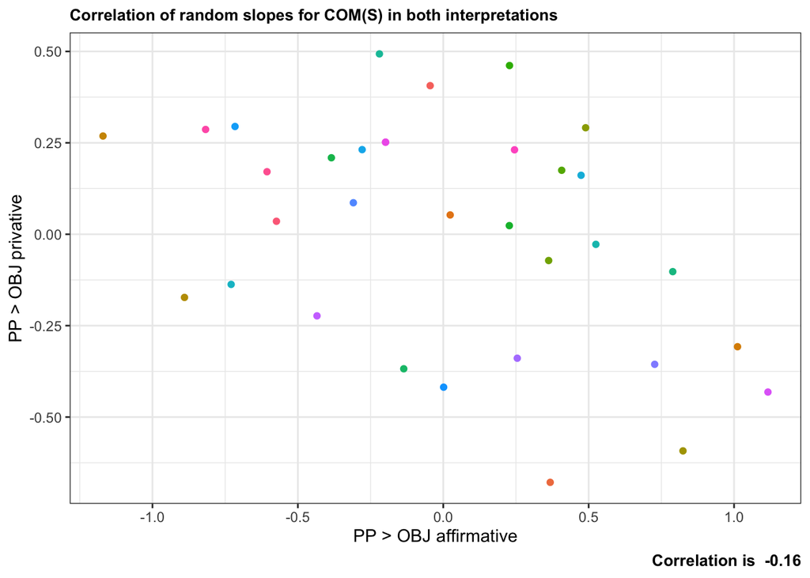

```r
ggplot(ranef.df, aes(x = COMS_aff, y = COMS_priv)) +
  geom_point(aes(color = participants), show.legend = FALSE) +
  labs(x = "PP > OBJ affirmative",
       y = "PP > OBJ privative",
       subtitle = "Correlation of random slopes for COM(S) in both interpretations",
       caption = paste("Correlation is ", round(cor_vals$sdcor[9], 2))) +
  theme_bw() +
  theme(plot.caption = element_text(face = "bold", size = 10),
        plot.subtitle = element_text(face = "bold", size = 10))
```

```r
ggsave("../Figures/EXP_1.COM_S_aff_priv.pdf")
```

The model already indicates that the subject-specific variance is much smaller for privative interpretations of COM(S) than for affirmative interpretations, which can be further witnessed from the visualization.

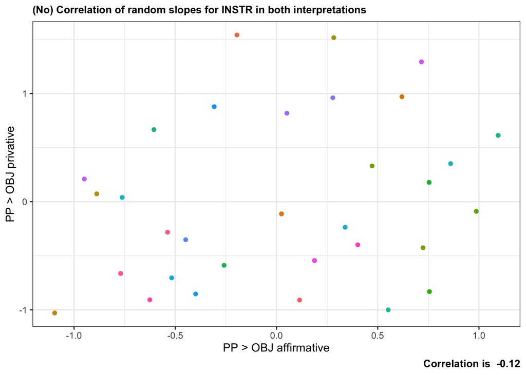

```r
ggplot(ranef.df, aes(x = INSTR_aff, y = INSTR_priv)) +
  geom_point(aes(color = participants), show.legend = FALSE) +
  labs(x = "PP > OBJ affirmative",
       y = "PP > OBJ privative",
       subtitle = "(No) Correlation of random slopes for INSTR in both interpretations",
       caption = paste("Correlation is ", round(cor_vals$sdcor[6], 2))) +
  theme_bw() +
  theme(plot.caption = element_text(face = "bold", size = 10),
        plot.subtitle = element_text(face = "bold", size = 10))
```

```r
ggsave("../Figures/EXP_1.INSTR_aff_priv.pdf")
```

Apparently no correlation here.